# BERT_HomeWork

### Jacinto Jimenez

Build a learning-based entity extraction model (e.g., a custom bert model) to extract the store_number from the transaction_descriptor. The dataset contains three sections: train, validate, and test. Write a document explaining your approach to this problem.

### What is BERT NLP Model?

BERT NLP model is a group of Transformers encoders stacked on each other. – BERT is a precise, huge transformer masked language model in more technical terms.

Models are the output of an algorithm run on data, including the procedures used to make predictions on data.

```python
#Import the bert functions
!wget https://raw.githubusercontent.com/google-research/bert/master/modeling.py
!wget https://raw.githubusercontent.com/google-research/bert/master/optimization.py
!wget https://raw.githubusercontent.com/google-research/bert/master/run_classifier.py
!wget https://raw.githubusercontent.com/google-research/bert/master/tokenization.py
```

```python
import numpy as np # linear algebra
import re, os
import pandas as pd # data processing, CSV file I/O (e.g. pd.read_csv)
from sklearn.preprocessing import LabelEncoder
from nltk.corpus import stopwords
from sklearn.model_selection import train_test_split
import tensorflow as tf
import nltk
nltk.download('stopwords')
from nltk.corpus import stopwords
import datetime
import matplotlib
from datetime import datetime

# BERT
import optimization
import run_classifier
import tokenization
import tensorflow_hub as hub
```

```
WARNING:tensorflow:From C:\Users\PC-8783213\Desktop\Data Science\NLP\BERTHomeWork1\optimization.py:87: The name tf.train.Optimizer is deprecated. Please use tf.compat.v1.train.Optimizer instead.
```

```python
df = pd.read_csv('C:/Users/PC-8783213/Desktop/Data Science/NLP/Use Bert NLP/BERTNLPHomeWork/Data/HomeworkExercise.csv')
```

```python
df.head()
```

|  | transaction_descriptor | store_number | dataset |
| --- | --- | --- | --- |
| 0 | DOLRTREE 2257 00022574 ROSWELL | 2257 | train |
| 1 | AUTOZONE #3547 | 3547 | train |
| 2 | TGI FRIDAYS 1485 0000 | 1485 | train |
| 3 | BUFFALO WILD WINGS 003 | 3 | train |
| 4 | J. CREW #568 0 | 568 | train |

```python
df.shape
```

```
(300, 3)
```

Starts with “#” and name hash Starts with “MCDONALD’S” named f_val Starts only with digits names ss_s Starts with “FOOTWARE”, “STORE”, “PETRO” it gets named st_n The function will return the parameters of hash ,f_val,st_n,ss_s Are the four conditions that I observed from the input in order to convert the string into Binary, either 0 or 1

```python
def conv_data(S):
    # 1. Starts with “#” and name hash assign either 1 if found and 0 if not found
    if type(re.search('#',S))==re.Match:
        hash=1
    else:
        hash=0
    # 2. Starts with “MCDONALD’S” named f_val assign either 1 if found and 0 if not found
    if type(re.search("MCDONALD'S",S))==re.Match:
        f_val=1
    else:
        f_val=0
    stp_s= S.split()
    # 3. Starts only with digits names ss_s assign either 1 if found and 0 if not found
    for i in range(len(stp_s)):
        if stp_s[i].isdigit():
            ss_s=1
            break
        else:
            ss_s=0
    # 4. Starts with “FOOTWARE”, “STORE”, “PETRO” it gets named st_n assign either 1 if found and 0 if not found
    if (type(re.search(" FOOTWEAR",S))==re.Match) or (type(re.search(" STORE",S))==re.Match) or (type(
        re.search(" PETRO",S))==re.Match):
        st_n=1
    else:
        st_n=0
    return hash ,f_val,st_n,ss_s
```

```python
Labels=[]
dim = df.shape
for i in range(dim[0]):
    hash_val,ff_val,sts_n,s_s_s=conv_data(df['transaction_descriptor'][i])
    if hash_val==1:
        Labels.append('Hash_String')
    elif ff_val==1:
        Labels.append('F_strings')
    elif sts_n==1:
        Labels.append('Store_string')
    elif s_s_s==1:
        Labels.append('PETRO_string')
    else:
        Labels.append('Unkown_string')
```

```python
Labels=pd.Series(Labels)
```

```python
Labels.shape
```

```
(300,)
```

```python
for label in np.unique(Labels):
    print(label)
```

```
F_strings
Hash_String
PETRO_string
Store_string
Unkown_string
```

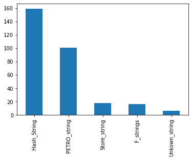

```python
Labels.value_counts().sort_values(ascending=False).plot(kind='bar')
```

```python
le = LabelEncoder()
Label = le.fit_transform(Labels)
print(Label)
```

```
[2 1 2 2 1 2 2 3 2 1 1 2 1 1 1 1 2 0 2 1 0 2 3 2 2 1 2 2 1 0 1 2 1 1 2 2 3
 0 1 2 0 1 1 4 1 2 1 2 2 2 1 2 1 1 2 1 1 1 1 1 1 1 1 1 2 2 1 1 2 3 3 2 1 1
 0 2 3 2 2 1 1 2 2 1 2 1 1 1 3 1 0 3 2 2 4 1 1 1 1 2 2 3 1 1 0 1 2 2 1 2 1
 1 1 1 1 1 2 2 1 2 1 1 1 1 1 1 1 2 1 1 4 3 1 2 3 2 2 0 2 2 3 2 2 1 2 1 2 1
 2 1 1 1 4 2 1 2 1 2 2 2 2 2 1 2 2 1 2 2 2 1 1 1 1 2 1 1 1 2 1 1 2 2 1 1 1
 2 2 2 1 1 1 1 1 1 1 1 1 2 1 2 1 1 2 1 1 1 2 1 1 3 1 2 1 1 2 1 2 1 1 1 1 2
 1 4 2 1 1 1 1 1 2 2 2 2 2 1 3 1 1 1 1 1 1 1 1 1 0 0 0 1 1 1 2 0 1 1 0 1 2
 0 1 1 2 1 3 1 1 2 1 1 1 1 2 2 2 1 2 1 1 1 1 1 3 3 2 1 3 2 1 1 4 1 2 2 1 0
 1 1 1 2]
```

```python
REPLACE_BY_SPACE_RE = re.compile('[/(){}\[\]\|@,;]')
BAD_SYMBOLS_RE = re.compile('[^0-9a-z +_]')
STOPWORDS = set(stopwords.words('english'))

def clean_text(text):
    """
        text: a string

        return: modified initial string
    """
    text = text.lower() # lowercase text
    text = REPLACE_BY_SPACE_RE.sub(' ', text) # replace REPLACE_BY_SPACE_RE symbols by space in text. substitute the matched string in REPLACE_BY_SPACE_RE with space.
#     text = re.sub(r'\W+', '', text)
    text = ' '.join(word for word in text.split() if word not in STOPWORDS) # remove stopwors from text
    return text
```

```python
df['transaction_descriptor'] = df['transaction_descriptor'].apply(clean_text)
df.head()
```

|  | transaction_descriptor | store_number | dataset |
| --- | --- | --- | --- |
| 0 | dolrtree 2257 00022574 roswell | 2257 | train |
| 1 | autozone #3547 | 3547 | train |
| 2 | tgi fridays 1485 0000 | 1485 | train |
| 3 | buffalo wild wings 003 | 3 | train |
| 4 | j. crew #568 0 | 568 | train |

```python
def get_split(text1):
    l_total = []
    l_parcial = []
    if len(text1.split())//150 >0:
        n = len(text1.split())//150
    else:
        n = 1
    for w in range(n):
        if w == 0:
            l_parcial = text1.split()[:200]
            l_total.append(" ".join(l_parcial))
        else:
            l_parcial = text1.split()[w*150:w*150 + 200]
            l_total.append(" ".join(l_parcial))
    return l_total
```

```python
df['text_split'] = df['transaction_descriptor'].apply(get_split)
df.head()
```

|  | transaction_descriptor | store_number | dataset | text_split |
| --- | --- | --- | --- | --- |
| 0 | dolrtree 2257 00022574 roswell | 2257 | train | [dolrtree 2257 00022574 roswell] |
| 1 | autozone #3547 | 3547 | train | [autozone #3547] |
| 2 | tgi fridays 1485 0000 | 1485 | train | [tgi fridays 1485 0000] |
| 3 | buffalo wild wings 003 | 3 | train | [buffalo wild wings 003] |
| 4 | j. crew #568 0 | 568 | train | [j. crew #568 0] |

This class is just a wrapper around an internal HubModuleSplitter. It offers the same functionality, but with 'token'-based method names: e.g., one can use tokenize() instead of the more general and less informatively named split().

```python
BERT_MODEL_HUB = "https://tfhub.dev/google/bert_uncased_L-12_H-768_A-12/1"

def create_tokenizer_from_hub_module():
  """Get the vocab file and casing info from the Hub module."""
  with tf.Graph().as_default():
    bert_module = hub.Module(BERT_MODEL_HUB)
    tokenization_info = bert_module(signature="tokenization_info", as_dict=True)
    with tf.Session() as sess:
#     with tf.compat.v1.Session() as sess:
        vocab_file, do_lower_case = sess.run([tokenization_info["vocab_file"],
                                            tokenization_info["do_lower_case"]])

    return tokenization.FullTokenizer(
      vocab_file=vocab_file, do_lower_case=do_lower_case)

tokenizer = create_tokenizer_from_hub_module()
```

```
INFO:tensorflow:Saver not created because there are no variables in the graph to restore
```

```
INFO:tensorflow:Saver not created because there are no variables in the graph to restore
```

[output not shown]

[output not shown]

[output not shown]

[output not shown]

```python
len(tokenizer.vocab.keys())
```

```
30522
```

```python
df['label']=Label
X_train=df['transaction_descriptor']
```

```python
type(X_train.iloc[0])
```

```
str
```

```python
#Here is what the tokenised sample of the first training set observation looks like
print(tokenizer.tokenize(X_train.iloc[0]))
```

```
['do', '##lr', '##tree', '225', '##7', '000', '##22', '##57', '##4', 'ro', '##swell']
```

```python
X_train=df[['transaction_descriptor','label','text_split']]
```

```python
X_train.shape
```

```
(300, 3)
```

```python
train_l = []
label_l = []
index_l =[]
for idx,row in X_train.iterrows():
    for l in row['text_split']:
        train_l.append(l)
        label_l.append(row['label'])
        index_l.append(idx)
len(train_l), len(label_l), len(index_l)
```

```
(300, 300, 300)
```

```python
train_df = pd.DataFrame({'DATA_COLUMN':train_l, 'LABEL_COLUMN':label_l})
train_df.head()
```

|  | DATA_COLUMN | LABEL_COLUMN |
| --- | --- | --- |
| 0 | dolrtree 2257 00022574 roswell | 2 |
| 1 | autozone #3547 | 1 |
| 2 | tgi fridays 1485 0000 | 2 |
| 3 | buffalo wild wings 003 | 2 |
| 4 | j. crew #568 0 | 1 |

```python
# Use the InputExample class from BERT's run_classifier code to create examples from the data
train_InputExamples = train_df.apply(lambda x: run_classifier.InputExample(guid=None, # Globally unique ID for bookkeeping, unused in this example
                                                                   text_a = x['DATA_COLUMN'],
                                                                   text_b = None,
                                                                   label = x['LABEL_COLUMN']), axis = 1)
```

```python
train_InputExamples
```

```
0      <run_classifier.InputExample object at 0x00000...
1      <run_classifier.InputExample object at 0x00000...
2      <run_classifier.InputExample object at 0x00000...
3      <run_classifier.InputExample object at 0x00000...
4      <run_classifier.InputExample object at 0x00000...
                             ...
295    <run_classifier.InputExample object at 0x00000...
296    <run_classifier.InputExample object at 0x00000...
297    <run_classifier.InputExample object at 0x00000...
298    <run_classifier.InputExample object at 0x00000...
299    <run_classifier.InputExample object at 0x00000...
Length: 300, dtype: object
```

```python
print("Row 0 - guid of training set : ", train_InputExamples.iloc[0].guid)
print("\n__________\nRow 0 - text_a of training set : ", train_InputExamples.iloc[0].text_a)
print("\n__________\nRow 0 - text_b of training set : ", train_InputExamples.iloc[0].text_b)
print("\n__________\nRow 0 - label of training set : ", train_InputExamples.iloc[0].label)
```

```
Row 0 - guid of training set :  None

__________
Row 0 - text_a of training set :  dolrtree 2257 00022574 roswell

__________
Row 0 - text_b of training set :  None

__________
Row 0 - label of training set :  2
```

```python
BERT_MODEL_HUB = "https://tfhub.dev/google/bert_uncased_L-12_H-768_A-12/1"

def create_tokenizer_from_hub_module():
  """Get the vocab file and casing info from the Hub module."""
  with tf.Graph().as_default():
    bert_module = hub.Module(BERT_MODEL_HUB)
    tokenization_info = bert_module(signature="tokenization_info", as_dict=True)
    with tf.Session() as sess:
#     with tf.compat.v1.Session() as sess:
        vocab_file, do_lower_case = sess.run([tokenization_info["vocab_file"],
                                            tokenization_info["do_lower_case"]])

    return tokenization.FullTokenizer(
      vocab_file=vocab_file, do_lower_case=do_lower_case)

tokenizer = create_tokenizer_from_hub_module()
```

```
INFO:tensorflow:Saver not created because there are no variables in the graph to restore
```

```
INFO:tensorflow:Saver not created because there are no variables in the graph to restore
```

```python
len(tokenizer.vocab.keys())
```

```
30522
```

```python
print(tokenizer.tokenize(train_InputExamples.iloc[0].text_a))
```

```
['do', '##lr', '##tree', '225', '##7', '000', '##22', '##57', '##4', 'ro', '##swell']
```

```python
label_list = [x for x in np.unique(df.label)]
label_list
```

```
[0, 1, 2, 3, 4]
```

```python
MAX_SEQ_LENGTH = 200

train_features = run_classifier.convert_examples_to_features(train_InputExamples, label_list, MAX_SEQ_LENGTH, tokenizer)
```

```
WARNING:tensorflow:From C:\Users\PC-8783213\Desktop\Data Science\NLP\BERTHomeWork1\run_classifier.py:774: The name tf.logging.info is deprecated. Please use tf.compat.v1.logging.info instead.
```

```
WARNING:tensorflow:From C:\Users\PC-8783213\Desktop\Data Science\NLP\BERTHomeWork1\run_classifier.py:774: The name tf.logging.info is deprecated. Please use tf.compat.v1.logging.info instead.
```

```
INFO:tensorflow:Writing example 0 of 300
```

```
INFO:tensorflow:Writing example 0 of 300
```

```
INFO:tensorflow:*** Example ***
```

```
INFO:tensorflow:*** Example ***
```

```
INFO:tensorflow:guid: None
```

```
INFO:tensorflow:guid: None
```

```
INFO:tensorflow:tokens: [CLS] do ##lr ##tree 225 ##7 000 ##22 ##57 ##4 ro ##swell [SEP]
```

```
INFO:tensorflow:tokens: [CLS] do ##lr ##tree 225 ##7 000 ##22 ##57 ##4 ro ##swell [SEP]
```

[output not shown]

[output not shown]

[output not shown]

[output not shown]

[output not shown]

[output not shown]

```
INFO:tensorflow:label: 2 (id = 2)
```

```
INFO:tensorflow:label: 2 (id = 2)
```

```
INFO:tensorflow:*** Example ***
```

```
INFO:tensorflow:*** Example ***
```

```
INFO:tensorflow:guid: None
```

```
INFO:tensorflow:guid: None
```

```
INFO:tensorflow:tokens: [CLS] auto ##zone # 354 ##7 [SEP]
```

```
INFO:tensorflow:tokens: [CLS] auto ##zone # 354 ##7 [SEP]
```

[output not shown]

[output not shown]

[output not shown]

[output not shown]

[output not shown]

[output not shown]

```
INFO:tensorflow:label: 1 (id = 1)
```

```
INFO:tensorflow:label: 1 (id = 1)
```

```
INFO:tensorflow:*** Example ***
```

```
INFO:tensorflow:*** Example ***
```

```
INFO:tensorflow:guid: None
```

```
INFO:tensorflow:guid: None
```

```
INFO:tensorflow:tokens: [CLS] t ##gi fridays 148 ##5 000 ##0 [SEP]
```

```
INFO:tensorflow:tokens: [CLS] t ##gi fridays 148 ##5 000 ##0 [SEP]
```

[output not shown]

[output not shown]

[output not shown]

[output not shown]

[output not shown]

[output not shown]

```
INFO:tensorflow:label: 2 (id = 2)
```

```
INFO:tensorflow:label: 2 (id = 2)
```

```
INFO:tensorflow:*** Example ***
```

```
INFO:tensorflow:*** Example ***
```

```
INFO:tensorflow:guid: None
```

```
INFO:tensorflow:guid: None
```

```
INFO:tensorflow:tokens: [CLS] buffalo wild wings 00 ##3 [SEP]
```

```
INFO:tensorflow:tokens: [CLS] buffalo wild wings 00 ##3 [SEP]
```

[output not shown]

[output not shown]

[output not shown]

[output not shown]

[output not shown]

[output not shown]

```
INFO:tensorflow:label: 2 (id = 2)
```

```
INFO:tensorflow:label: 2 (id = 2)
```

```
INFO:tensorflow:*** Example ***
```

```
INFO:tensorflow:*** Example ***
```

```
INFO:tensorflow:guid: None
```

```
INFO:tensorflow:guid: None
```

```
INFO:tensorflow:tokens: [CLS] j . crew # 56 ##8 0 [SEP]
```

```
INFO:tensorflow:tokens: [CLS] j . crew # 56 ##8 0 [SEP]
```

[output not shown]

[output not shown]

[output not shown]

[output not shown]

[output not shown]

[output not shown]

```
INFO:tensorflow:label: 1 (id = 1)
```

```
INFO:tensorflow:label: 1 (id = 1)
```

```python
#Example on first observation in the training set
print("Sentence : ", train_InputExamples.iloc[0].text_a)
print("-"*30)
print("Tokens : ", tokenizer.tokenize(train_InputExamples.iloc[0].text_a))
print("-"*30)
print("Input IDs : ", train_features[0].input_ids)
print("-"*30)
print("Input Masks : ", train_features[0].input_mask)
print("-"*30)
print("Segment IDs : ", train_features[0].segment_ids)
```

```
Sentence :  dolrtree 2257 00022574 roswell
------------------------------
Tokens :  ['do', '##lr', '##tree', '225', '##7', '000', '##22', '##57', '##4', 'ro', '##swell']
------------------------------
Input IDs :  [101, 2079, 20974, 13334, 14993, 2581, 2199, 19317, 28311, 2549, 20996, 19228, 102, 0, 0, 0, 0, 0, 0, 0, 0, 0, 0, 0, 0, 0, 0, 0, 0, 0, 0, 0, 0, 0, 0, 0, 0, 0, 0, 0, 0, 0, 0, 0, 0, 0, 0, 0, 0, 0, 0, 0, 0, 0, 0, 0, 0, 0, 0, 0, 0, 0, 0, 0, 0, 0, 0, 0, 0, 0, 0, 0, 0, 0, 0, 0, 0, 0, 0, 0, 0,…
------------------------------
Input Masks :  [1, 1, 1, 1, 1, 1, 1, 1, 1, 1, 1, 1, 1, 0, 0, 0, 0, 0, 0, 0, 0, 0, 0, 0, 0, 0, 0, 0, 0, 0, 0, 0, 0, 0, 0, 0, 0, 0, 0, 0, 0, 0, 0, 0, 0, 0, 0, 0, 0, 0, 0, 0, 0, 0, 0, 0, 0, 0, 0, 0, 0, 0, 0, 0, 0, 0, 0, 0, 0, 0, 0, 0, 0, 0, 0, 0, 0, 0, 0, 0, 0, 0, 0, 0, 0, 0, 0, 0, 0, 0, 0, 0, 0, 0, 0,…
------------------------------
Segment IDs :  [0, 0, 0, 0, 0, 0, 0, 0, 0, 0, 0, 0, 0, 0, 0, 0, 0, 0, 0, 0, 0, 0, 0, 0, 0, 0, 0, 0, 0, 0, 0, 0, 0, 0, 0, 0, 0, 0, 0, 0, 0, 0, 0, 0, 0, 0, 0, 0, 0, 0, 0, 0, 0, 0, 0, 0, 0, 0, 0, 0, 0, 0, 0, 0, 0, 0, 0, 0, 0, 0, 0, 0, 0, 0, 0, 0, 0, 0, 0, 0, 0, 0, 0, 0, 0, 0, 0, 0, 0, 0, 0, 0, 0, 0, 0,…
```

```python
def create_model(is_predicting, input_ids, input_mask, segment_ids, labels,
                 num_labels):
    """
    Create models for prediction using BERT.
    """
    bert_module = hub.Module(
        BERT_MODEL_HUB,
        trainable=True)
    bert_inputs = dict(
      input_ids=input_ids,
      input_mask=input_mask,
      segment_ids=segment_ids)
    bert_outputs = bert_module(
      inputs=bert_inputs,
      signature="tokens",
      as_dict=True)

    # Use "pooled_output" for classification tasks on an entire sentence.
    # Use "sequence_outputs" for token-level output.
    output_layer = bert_outputs["pooled_output"]
    # with tf.Session() as sess:
    output_layer1 = bert_outputs["pooled_output"]
    # output_layer1 = 999
    hidden_size = output_layer.shape[-1].value

    # Create our own layer to tune for politeness data.
    output_weights = tf.get_variable(
      "output_weights", [num_labels, hidden_size],
      initializer=tf.truncated_normal_initializer(stddev=0.02))

    output_bias = tf.get_variable(
      "output_bias", [num_labels], initializer=tf.zeros_initializer())
    with tf.variable_scope("loss"):

        # Dropout helps prevent overfitting
        output_layer = tf.nn.dropout(output_layer, keep_prob=0.8)

        logits = tf.matmul(output_layer, output_weights, transpose_b=True)
        logits = tf.nn.bias_add(logits, output_bias)
        log_probs = tf.nn.log_softmax(logits, axis=-1)

        # Convert labels into one-hot encoding
        one_hot_labels = tf.one_hot(labels, depth=num_labels, dtype=tf.float32)
        predicted_labels = tf.squeeze(tf.argmax(log_probs, axis=-1, output_type=tf.int32))
        # If we're predicting, we want predicted labels and the probabiltiies.
        if is_predicting:
            return (predicted_labels, log_probs, output_layer1)

        # If we're train/eval, compute loss between predicted and actual label
        per_example_loss = -tf.reduce_sum(one_hot_labels * log_probs, axis=-1)
        loss = tf.reduce_mean(per_example_loss)

        return (loss, predicted_labels, log_probs)
```

```python
def model_fn_builder(num_labels, learning_rate, num_train_steps,
                     num_warmup_steps):
    """Returns `model_fn` closure for TPUEstimator."""

    def model_fn(features, labels, mode, params):  # pylint: disable=unused-argument
        """The `model_fn` for TPUEstimator."""

        input_ids = features["input_ids"]
        input_mask = features["input_mask"]
        segment_ids = features["segment_ids"]
        label_ids = features["label_ids"]

        is_predicting = (mode == tf.estimator.ModeKeys.PREDICT)

        # TRAIN and EVAL
        if not is_predicting:

            (loss, predicted_labels, log_probs) = create_model(
            is_predicting, input_ids, input_mask, segment_ids, label_ids, num_labels)
            train_op = optimization.create_optimizer(
              loss, learning_rate, num_train_steps, num_warmup_steps, use_tpu=False)

            # Calculate evaluation metrics.
            def metric_fn(label_ids, predicted_labels):
                accuracy = tf.metrics.accuracy(label_ids, predicted_labels)
                true_pos = tf.metrics.true_positives(
                    label_ids,
                    predicted_labels)
                true_neg = tf.metrics.true_negatives(
                    label_ids,
                    predicted_labels)
                false_pos = tf.metrics.false_positives(
                    label_ids,
                    predicted_labels)
                false_neg = tf.metrics.false_negatives(
                    label_ids,
                    predicted_labels)
                return {
                    "eval_accuracy": accuracy,
                    "true_positives": true_pos,
                    "true_negatives": true_neg,
                    "false_positives": false_pos,
                    "false_negatives": false_neg,
                    }

            eval_metrics = metric_fn(label_ids, predicted_labels)

            if mode == tf.estimator.ModeKeys.TRAIN:
                return tf.estimator.EstimatorSpec(mode=mode,
                  loss=loss,
                  train_op=train_op)
            else:
                return tf.estimator.EstimatorSpec(mode=mode,
                    loss=loss,
                    eval_metric_ops=eval_metrics)
        else:
            (predicted_labels, log_probs, output_layer) = create_model(
            is_predicting, input_ids, input_mask, segment_ids, label_ids, num_labels)
            predictions = {
              'probabilities': log_probs,
              'labels': predicted_labels,
              'pooled_output': output_layer
            }
        return tf.estimator.EstimatorSpec(mode, predictions=predictions)

    # Return the actual model function in the closure
    return model_fn
```

```python
# Set the output directory for saving model file
OUTPUT_DIR = '/bert_news_category'

#@markdown Whether or not to clear/delete the directory and create a new one
DO_DELETE = True #@param {type:"boolean"}

if DO_DELETE:
    try:
        tf.gfile.DeleteRecursively(OUTPUT_DIR)
#         tf.compat.v1.gfile.DeleteRecursively(OUTPUT_DIR)
    except:
        pass

tf.gfile.MakeDirs(OUTPUT_DIR)
print('***** Model output directory: {} *****'.format(OUTPUT_DIR))
```

```
WARNING:tensorflow:From C:\Users\PC-8783213\AppData\Local\Temp\ipykernel_3064\2725379644.py:9: The name tf.gfile.DeleteRecursively is deprecated. Please use tf.io.gfile.rmtree instead.
```

```
WARNING:tensorflow:From C:\Users\PC-8783213\AppData\Local\Temp\ipykernel_3064\2725379644.py:9: The name tf.gfile.DeleteRecursively is deprecated. Please use tf.io.gfile.rmtree instead.
```

```
WARNING:tensorflow:From C:\Users\PC-8783213\AppData\Local\Temp\ipykernel_3064\2725379644.py:14: The name tf.gfile.MakeDirs is deprecated. Please use tf.io.gfile.makedirs instead.
```

```
WARNING:tensorflow:From C:\Users\PC-8783213\AppData\Local\Temp\ipykernel_3064\2725379644.py:14: The name tf.gfile.MakeDirs is deprecated. Please use tf.io.gfile.makedirs instead.
```

```
***** Model output directory: /bert_news_category *****
```

```python
BATCH_SIZE = 16
LEARNING_RATE = 2e-5
NUM_TRAIN_EPOCHS = 1.0
# Warmup is a period of time where the learning rate is small and gradually increases--usually helps training.
WARMUP_PROPORTION = 0.1
# Model configs
SAVE_CHECKPOINTS_STEPS = 300
SAVE_SUMMARY_STEPS = 100

# Compute train and warmup steps from batch size
num_train_steps = int(len(train_features) / BATCH_SIZE * NUM_TRAIN_EPOCHS)
num_warmup_steps = int(num_train_steps * WARMUP_PROPORTION)

# Specify output directory and number of checkpoint steps to save
run_config = tf.estimator.RunConfig(
    model_dir=OUTPUT_DIR,
    save_summary_steps=SAVE_SUMMARY_STEPS,
    save_checkpoints_steps=SAVE_CHECKPOINTS_STEPS)
# Specify output directory and number of checkpoint steps to save
run_config = tf.estimator.RunConfig(
    model_dir=OUTPUT_DIR,
    save_summary_steps=SAVE_SUMMARY_STEPS,
    save_checkpoints_steps=SAVE_CHECKPOINTS_STEPS)
```

```python
num_train_steps, len(label_list)
```

```
(18, 5)
```

```python
model_fn = model_fn_builder(
  num_labels=len(label_list),
  learning_rate=LEARNING_RATE,
  num_train_steps=num_train_steps,
  num_warmup_steps=num_warmup_steps)

estimator = tf.estimator.Estimator(
  model_fn=model_fn,
  config=run_config,
  params={"batch_size": BATCH_SIZE})
```

[output not shown]

[output not shown]

```python
train_input_fn = run_classifier.input_fn_builder(
    features=train_features,
    seq_length=MAX_SEQ_LENGTH,
    is_training=True,
    drop_remainder=False)
```

```python
# Training
print(f'Beginning Training!')
current_time = datetime.now()
estimator.train(input_fn=train_input_fn, max_steps=num_train_steps)
print("Training took time ", datetime.now() - current_time)
```

```
Beginning Training!
WARNING:tensorflow:From /usr/local/lib/python3.7/dist-packages/tensorflow_core/python/training/training_util.py:236: Variable.initialized_value (from tensorflow.python.ops.variables) is deprecated and will be removed in a future version.
Instructions for updating:
Use Variable.read_value. Variables in 2.X are initialized automatically both in eager and graph (inside tf.defun) contexts.
```

[output not shown]

```
INFO:tensorflow:Calling model_fn.
```

```
INFO:tensorflow:Calling model_fn.
```

```
INFO:tensorflow:Saver not created because there are no variables in the graph to restore
```

```
INFO:tensorflow:Saver not created because there are no variables in the graph to restore
```

[output not shown]

[output not shown]

```
WARNING:tensorflow:From /content/optimization.py:27: The name tf.train.get_or_create_global_step is deprecated. Please use tf.compat.v1.train.get_or_create_global_step instead.
```

```
WARNING:tensorflow:From /content/optimization.py:27: The name tf.train.get_or_create_global_step is deprecated. Please use tf.compat.v1.train.get_or_create_global_step instead.
```

```
WARNING:tensorflow:From /content/optimization.py:32: The name tf.train.polynomial_decay is deprecated. Please use tf.compat.v1.train.polynomial_decay instead.
```

```
WARNING:tensorflow:From /content/optimization.py:32: The name tf.train.polynomial_decay is deprecated. Please use tf.compat.v1.train.polynomial_decay instead.
```

```
WARNING:tensorflow:From /content/optimization.py:70: The name tf.trainable_variables is deprecated. Please use tf.compat.v1.trainable_variables instead.
```

```
WARNING:tensorflow:From /content/optimization.py:70: The name tf.trainable_variables is deprecated. Please use tf.compat.v1.trainable_variables instead.
```

[output not shown]

[output not shown]

```
INFO:tensorflow:Done calling model_fn.
```

```
INFO:tensorflow:Done calling model_fn.
```

```
INFO:tensorflow:Create CheckpointSaverHook.
```

```
INFO:tensorflow:Create CheckpointSaverHook.
```

```
INFO:tensorflow:Graph was finalized.
```

```
INFO:tensorflow:Graph was finalized.
```

```
INFO:tensorflow:Running local_init_op.
```

```
INFO:tensorflow:Running local_init_op.
```

```
INFO:tensorflow:Done running local_init_op.
```

```
INFO:tensorflow:Done running local_init_op.
```

```
INFO:tensorflow:Saving checkpoints for 0 into /bert_news_category/model.ckpt.
```

```
INFO:tensorflow:Saving checkpoints for 0 into /bert_news_category/model.ckpt.
```

```
INFO:tensorflow:loss = 1.6556565, step = 1
```

```
INFO:tensorflow:loss = 1.6556565, step = 1
```

```
INFO:tensorflow:Saving checkpoints for 18 into /bert_news_category/model.ckpt.
```

```
INFO:tensorflow:Saving checkpoints for 18 into /bert_news_category/model.ckpt.
```

```
INFO:tensorflow:Loss for final step: 0.9200936.
```

```
INFO:tensorflow:Loss for final step: 0.9200936.
```

```
Training took time  0:10:37.991200
```

```python
estimator.evaluate(input_fn=train_input_fn, steps=1)
```

```
INFO:tensorflow:Calling model_fn.
```

```
INFO:tensorflow:Calling model_fn.
```

```
INFO:tensorflow:Saver not created because there are no variables in the graph to restore
```

```
INFO:tensorflow:Saver not created because there are no variables in the graph to restore
```

```
INFO:tensorflow:Done calling model_fn.
```

```
INFO:tensorflow:Done calling model_fn.
```

```
INFO:tensorflow:Starting evaluation at 2022-05-23T05:18:49Z
```

```
INFO:tensorflow:Starting evaluation at 2022-05-23T05:18:49Z
```

```
INFO:tensorflow:Graph was finalized.
```

```
INFO:tensorflow:Graph was finalized.
```

```
INFO:tensorflow:Restoring parameters from /bert_news_category/model.ckpt-18
```

```
INFO:tensorflow:Restoring parameters from /bert_news_category/model.ckpt-18
```

```
INFO:tensorflow:Running local_init_op.
```

```
INFO:tensorflow:Running local_init_op.
```

```
INFO:tensorflow:Done running local_init_op.
```

```
INFO:tensorflow:Done running local_init_op.
```

```
INFO:tensorflow:Evaluation [1/1]
```

```
INFO:tensorflow:Evaluation [1/1]
```

```
INFO:tensorflow:Finished evaluation at 2022-05-23-05:19:11
```

```
INFO:tensorflow:Finished evaluation at 2022-05-23-05:19:11
```

```
INFO:tensorflow:Saving dict for global step 18: eval_accuracy = 0.8125, false_negatives = 0.0, false_positives = 1.0, global_step = 18, loss = 0.7765753, true_negatives = 0.0, true_positives = 15.0
```

```
INFO:tensorflow:Saving dict for global step 18: eval_accuracy = 0.8125, false_negatives = 0.0, false_positives = 1.0, global_step = 18, loss = 0.7765753, true_negatives = 0.0, true_positives = 15.0
```

```
INFO:tensorflow:Saving 'checkpoint_path' summary for global step 18: /bert_news_category/model.ckpt-18
```

```
INFO:tensorflow:Saving 'checkpoint_path' summary for global step 18: /bert_news_category/model.ckpt-18
```

```
{'eval_accuracy': 0.8125,
 'false_negatives': 0.0,
 'false_positives': 1.0,
 'global_step': 18,
 'loss': 0.7765753,
 'true_negatives': 0.0,
 'true_positives': 15.0}
```

A few other pre-trained models are implemented off-the-shelf in run_classifier.py, so it should be straightforward to follow those examples to use BERT for any single-sentence or sentence-pair classification task.